# IE2152 Statistics for IE Project Final Project

```r
"FOR GNP"
```

```
## [1] "FOR GNP"
```

```r
xbar5<-mean(data_22$GNP); xbar5
```

```
## [1] 2884909571
```

```r
sd5<-sd(data_22$GNP); sd5
```

```
## [1] 4454768144
```

```r
n5<-42
E5 <- qnorm(.975)*sd5/sqrt(n5); E5
```

```
## [1] 1347251113
```

```r
xbar5 + c(-E5, E5)
```

```
## [1] 1537658458 4232160685
```

```r
z.test(data_22$GNP,alternative="two.sided",sigma.x =sd5,conf.level = 0.95)$conf.int
```

```
## [1] 1537658458 4232160685
## attr(,"conf.level")
## [1] 0.95
```

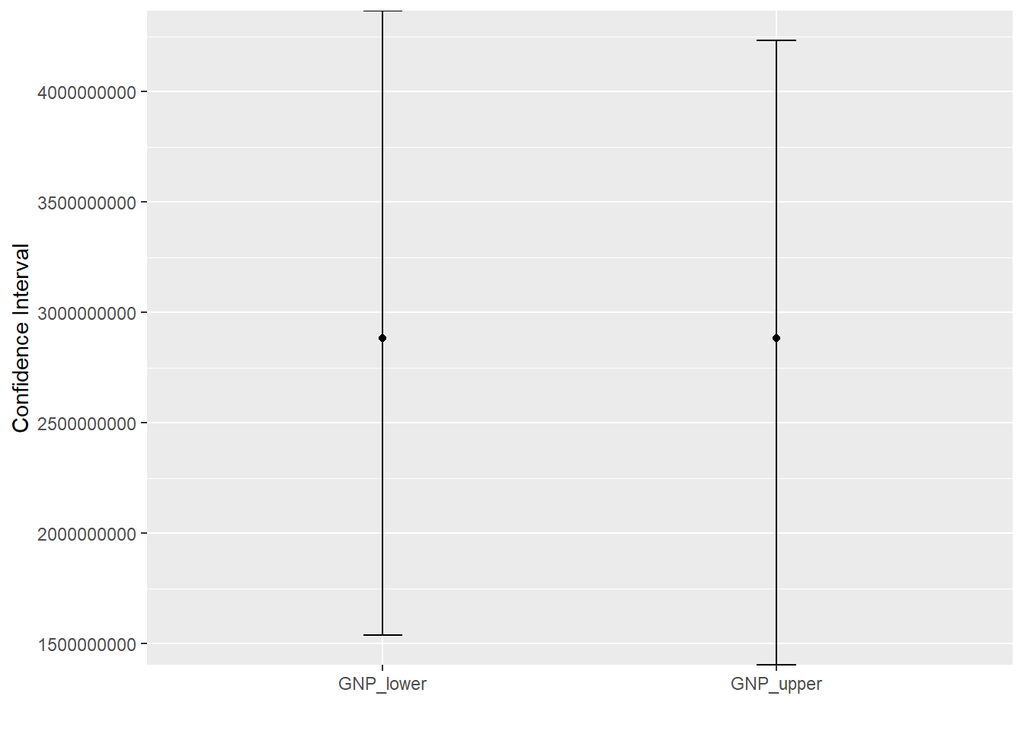

```r
ci.plot(c('GNP_lower', 'GNP_upper'),xbar5,c(E5,Inf),c(Inf,E5),'add')
```

```r
#If we used t-statistic instead of z-statistic, the CI will be found as:
E52 <- qt(.975,df=n5-1)*sd5/sqrt(n5); E52
```

```
## [1] 1388203478
```

```r
xbar5 + c(-E52, E52)
```

```
## [1] 1496706093 4273113050
```

```r
t.test(data_22$GNP,alternative="two.sided", conf.level=0.95)$conf.int
```

```
## [1] 1496706093 4273113050
## attr(,"conf.level")
## [1] 0.95
```

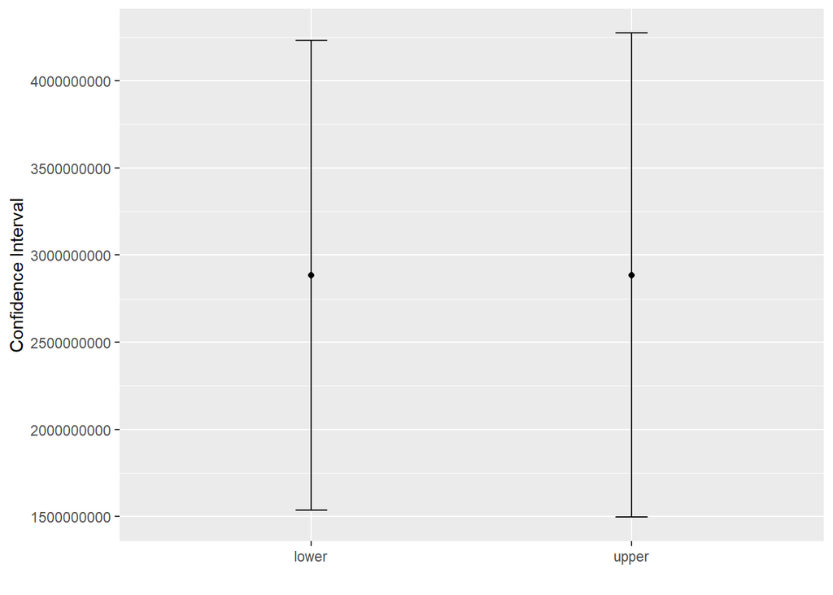

```r
ci.plot(c('lower', 'upper'),xbar5,c(E5,E52),c(E5,E52),'add')
```

```r
P <- qt(.975,df=n5-1)* sd5*sqrt(1+1/n5); P
```

```
## [1] 9103058969
```

```r
xbar5 + c(-P, P)
```

```
## [1] -6218149398 11987968540
```

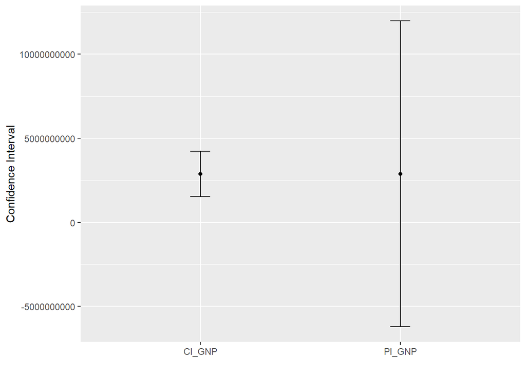

```r
ci.plot(c('CI_GNP', 'PI_GNP'),xbar5,c(E5, P),c(E5,P),'add')
```

…

#### 3.2.1.2. Confidence Intervals for the Population Variance of a Single Sample

Instead of the normally distributed sample calculation, the calculation is made according to the chi square distribution via using sample mean, variance, and standard deviation to find confidence intervals for the population variance. All results were commented in word documents …

```r
"FOR CURRENT EXPENDITURES"
```

```
## [1] "FOR CURRENT EXPENDITURES"
```

```r
#Find sample size, sample mean and sample variance
n<-length(data_22$CE); n
```

```
## [1] 42
```

```r
xbar<-mean(data_22$CE); xbar
```

```
## [1] 467141360
```

```r
var<-var(data_22$CE); var
```

```
## [1] 432804216879521536
```

```r
sd<- sd(data_22$CE); sd
```

```
## [1] 657878573
```

```r
#Alternatively, we can use varTest() function from EnvStats package.
require(EnvStats)
sigmasqCI<-varTest(data_22$CE, alternative="two.sided",conf.level=0.95,sigma.squared = var)$conf.int; sigmasqCI
```

```
##                LCL                UCL
## 293011977656920768 703760129104281856
## attr(,"conf.level")
## [1] 0.95
```

```r
sigmaCI<-sqrt(sigmasqCI); sigmaCI
```

```
##       LCL       UCL
## 541305808 838904124
## attr(,"conf.level")
## [1] 0.95
```

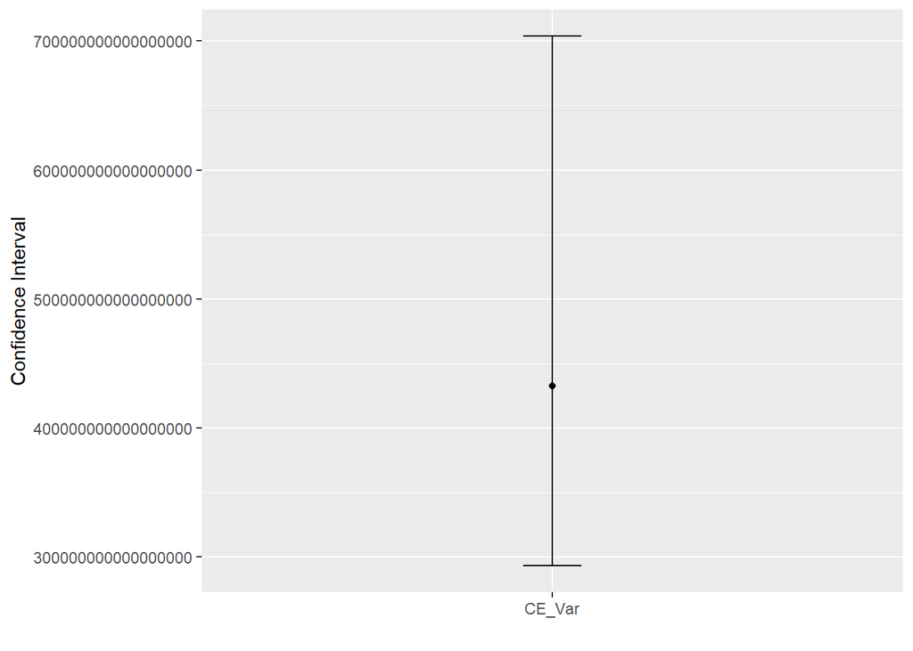

```r
ci.plot('CE_Var',var,sigmasqCI[1],sigmasqCI[2],'multiply')
```

```r
"FOR PERSONNEL EXPENDITURES"
```

```
## [1] "FOR PERSONNEL EXPENDITURES"
```

```r
n1<-length(data_22$PE); n1
```

```
## [1] 42
```

```r
xbar1<-mean(data_22$PE); xbar1
```

```
## [1] 394109263
```

```r
var1<-var(data_22$PE); var1
```

```
## [1] 307348250641565056
```

```r
sd1<- sd(data_22$PE); sd1
```

```
## [1] 554389981
```

```r
#Alternatively, we can use varTest() function from EnvStats package.
require(EnvStats)
sigmasqCI<-varTest(data_22$PE, alternative="two.sided",conf.level=0.95,sigma.squared = var1)$conf.int; sigmasqCI
```

```
##                LCL                UCL
## 208077267359316768 499762793696840512
## attr(,"conf.level")
## [1] 0.95
```

```r
sigmaCI<-sqrt(sigmasqCI); sigmaCI
```

```
##       LCL       UCL
## 456154872 706939031
## attr(,"conf.level")
## [1] 0.95
```

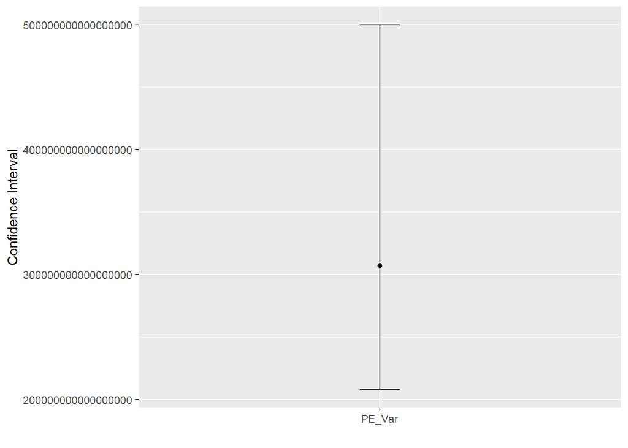

```r
ci.plot('PE_Var',var1,sigmasqCI[1],sigmasqCI[2],'multiply')
```

```r
"FOR OTHER CURRENT EXPENDITURES"
```

```
## [1] "FOR OTHER CURRENT EXPENDITURES"
```

```r
n2<-length(data_22$OCE); n2
```

```
## [1] 42
```

```r
xbar2<-mean(data_22$OCE); xbar2
```

```
## [1] 73032098
```

```r
var2<-var(data_22$OCE); var2
```

```
## [1] 10756865022613600
```

```r
sd2<- sd(data_22$OCE); sd2
```

```
## [1] 103715308
```

```r
require(EnvStats)
sigmasqCI<-varTest(data_22$OCE, alternative="two.sided",conf.level=0.95,sigma.squared = var2)$conf.int; sigmasqCI
```

```
##               LCL               UCL
##  7282485176298436 17491171346833688
## attr(,"conf.level")
## [1] 0.95
```

```r
sigmaCI<-sqrt(sigmasqCI); sigmaCI
```

```
##       LCL       UCL
##  85337478 132254192
## attr(,"conf.level")
## [1] 0.95
```

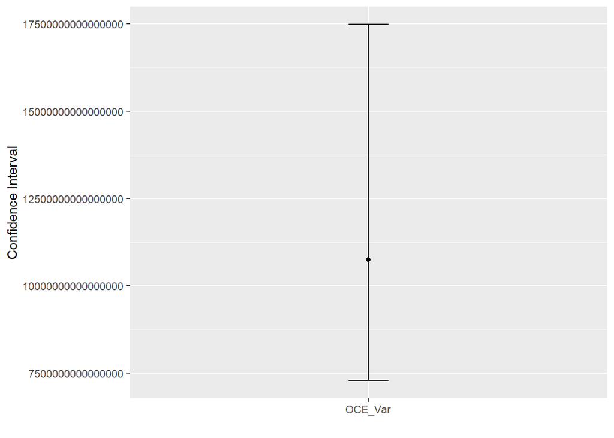

```r
ci.plot('OCE_Var',var2,sigmasqCI[1],sigmasqCI[2],'multiply')
```

```r
"FOR DEFENCE"
```

```
## [1] "FOR DEFENCE"
```

```r
n3<-length(data_22$D); n3
```

```
## [1] 42
```

```r
xbar3<-mean(data_22$D); xbar3
```

```
## [1] 68808754
```

```r
var3<-var(data_22$D); var3
```

```
## [1] 8362922193236486
```

```r
sd3<- sd(data_22$D); sd3
```

```
## [1] 91449014
```

```r
require(EnvStats)
sigmasqCI<-varTest(data_22$D, alternative="two.sided",conf.level=0.95,sigma.squared = var3)$conf.int; sigmasqCI
```

```
##               LCL               UCL
##  5661766395204270 13598507068242126
## attr(,"conf.level")
## [1] 0.95
```

```r
sigmaCI<-sqrt(sigmasqCI); sigmaCI
```

```
##       LCL       UCL
##  75244710 116612637
## attr(,"conf.level")
## [1] 0.95
```

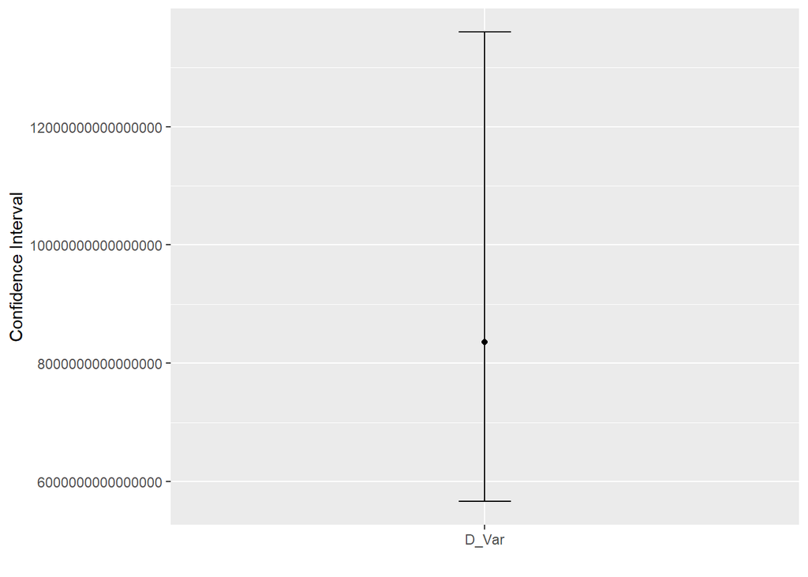

```r
ci.plot('D_Var',var3,sigmasqCI[1],sigmasqCI[2],'multiply')
```

```r
"FOR GNP"
```

```
## [1] "FOR GNP"
```

```r
n4<-length(data_22$GNP); n4
```

```
## [1] 42
```

```r
xbar4<-mean(data_22$GNP); xbar4
```

```
## [1] 2884909571
```

```r
var4<-var(data_22$GNP); var4
```

```
## [1] 19844959216553959424
```

```r
sd4<- sd(data_22$GNP); sd4
```

```
## [1] 4454768144
```

```r
require(EnvStats)
sigmasqCI<-varTest(data_22$GNP, alternative="two.sided",conf.level=0.95,sigma.squared = var4)$conf.int; sigmasqCI
```

```
##                  LCL                  UCL
## 13435198918549504000 32268842390227734528
## attr(,"conf.level")
## [1] 0.95
```

```r
sigmaCI<-sqrt(sigmasqCI); sigmaCI
```

```
##        LCL        UCL
## 3665405696 5680567084
## attr(,"conf.level")
## [1] 0.95
```

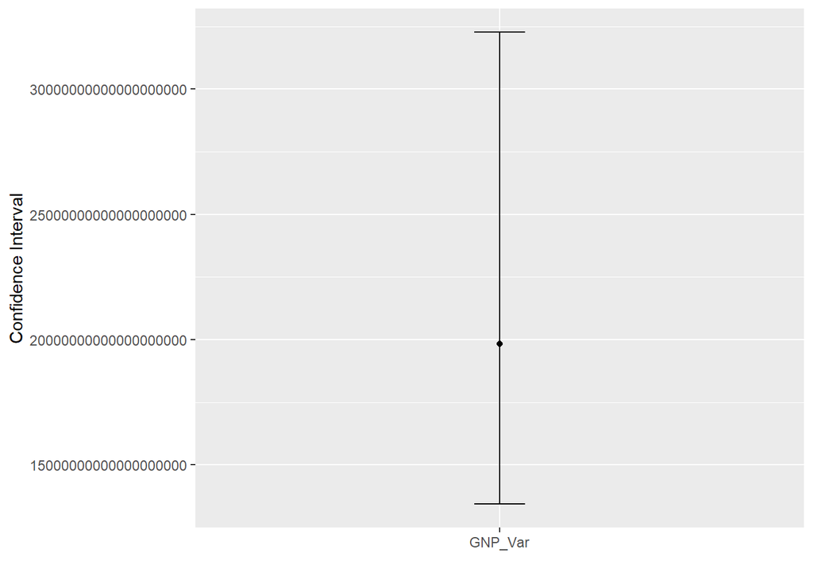

```r
ci.plot('GNP_Var',var4,sigmasqCI[1],sigmasqCI[2],'multiply')
```

…

#### 3.2.1.3. Confidence Intervals for the Difference of Population Means/Proportions of Two Samples

Since, population standard deviation is unknown and our sample size is 42, z test was applied for calculating confidence intervals for difference of population mean of two sample data. …

```r
"FOR  PERSONNEL EXPENDITURES and OTHER CURRENT EXPENDITURES CONFIDENCE INTERVAL ON MEANS"
```

```
## [1] "FOR  PERSONNEL EXPENDITURES and OTHER CURRENT EXPENDITURES CONFIDENCE INTERVAL ON MEANS"
```

```r
#Samples size, samples mean and standard deviation of samples was called.
n10<- length(data_22$PE) ; n10
```

```
## [1] 42
```

```r
n11<- length(data_22$OCE) ;n11
```

```
## [1] 42
```

```r
xbar10<-mean(data_22$PE);  xbar10
```

```
## [1] 394109263
```

```r
xbar11<- mean(data_22$OCE);  xbar11
```

```
## [1] 73032098
```

```r
sd10<-sd(data_22$PE); sd10
```

```
## [1] 554389981
```

```r
sd11<-sd(data_22$OCE); sd11
```

```
## [1] 103715308
```

```r
#zsum.test() function from the BSDA package was used. Since sample size is greater than 30 , we can approximately use z-statistic and then  the 95% CI was found.

zsum.test(xbar10, sd10, n10, xbar11, sd11, n11, alternative="two.sided", conf.level=0.95)
```

```
##
##  Two-sample z-Test
##
## data:  Summarized x and y
## z = 3.7, p-value = 0.0002
## alternative hypothesis: true difference in means is not equal to 0
## 95 percent confidence interval:
##  150504760 491649570
## sample estimates:
## mean of x mean of y
## 394109263  73032098
```

```r
#The standard error of the difference in means was calculated.
sed10<-sqrt(sd10^2/n10+sd11^2/n11); sed10
```

```
## [1] 87028336
```

```r
# zalpha/2 was multiplied with the standard error of the difference in means and the margin of error was obtained.
E10 <- qnorm(.95)*sed10; E10
```

```
## [1] 143148875
```

```r
#The difference of sample means was added and so,the confidence interval was found.
xbar10-xbar11 + c(-E10, E10)
```

```
## [1] 177928290 464226040
```

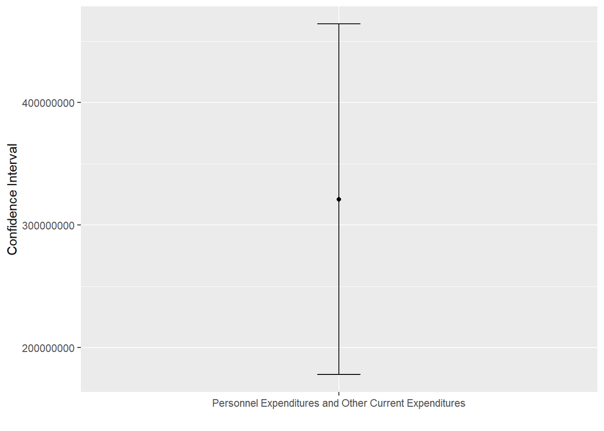

```r
#Then confidence intervals was plotted for both.
ci.plot("Personnel Expenditures and Other Current Expenditures",xbar10-xbar11,E10,E10,'add')
```

```r
"FOR  PERSONNEL EXPENDITURES and DEFENCE CONFIDENCE INTERVALS ON MEANS"
```

```
## [1] "FOR  PERSONNEL EXPENDITURES and DEFENCE CONFIDENCE INTERVALS ON MEANS"
```

```r
#Samples size, samples mean and standard deviation of samples was called.
n12<- length(data_22$PE) ; n12
```

```
## [1] 42
```

```r
n13<- length(data_22$D) ;n13
```

```
## [1] 42
```

```r
xbar12<-mean(data_22$PE);  xbar12
```

```
## [1] 394109263
```

```r
xbar13<- mean(data_22$D);  xbar13
```

```
## [1] 68808754
```

```r
sd12<-sd(data_22$PE); sd12
```

```
## [1] 554389981
```

```r
sd13<-sd(data_22$D); sd13
```

```
## [1] 91449014
```

```r
#zsum.test() function from the BSDA package was used. Since sample size is greater than 30 , we can approximately use z-statistic and then  the 95% CI was found.
zsum.test(xbar12, sd12, n12, xbar13, sd13, n13, alternative="two.sided", conf.level=0.95)
```

```
##
##  Two-sample z-Test
##
## data:  Summarized x and y
## z = 3.8, p-value = 0.0002
## alternative hypothesis: true difference in means is not equal to 0
## 95 percent confidence interval:
##  155371149 495229868
## sample estimates:
## mean of x mean of y
## 394109263  68808754
```

```r
#The standard error of the difference in means was calculated.
sed11<-sqrt(sd12^2/n12+sd13^2/n13); sed11
```

```
## [1] 86700246
```

```r
# zalpha/2 was multiplied with the standard error of the difference in means and the margin of error was obtained.
E11 <- qnorm(.95)*sed11; E11
```

```
## [1] 142609214
```

```r
#The difference of sample means was added and so,the confidence interval was found.
xbar12-xbar13 + c(-E11, E11)
```

```
## [1] 182691294 467909723
```

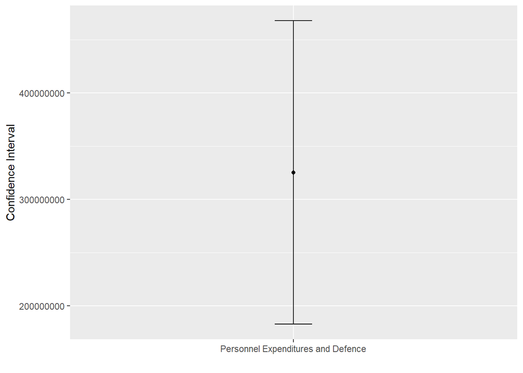

```r
#Then confidence intervals was plotted for both.
ci.plot("Personnel Expenditures and Defence",xbar12-xbar13,E11,E11,'add')
```

```r
"FOR  OTHER CURRENT EXPENDITURES and DEFENCE CONFIDENCE INTERVALS ON MEANS"
```

```
## [1] "FOR  OTHER CURRENT EXPENDITURES and DEFENCE CONFIDENCE INTERVALS ON MEANS"
```

```r
#Samples size, samples mean and standard deviation of samples was called.
n14<- length(data_22$OCE) ; n14
```

```
## [1] 42
```

```r
n15<- length(data_22$D) ;n15
```

```
## [1] 42
```

```r
xbar14<-mean(data_22$OCE);  xbar14
```

```
## [1] 73032098
```

```r
xbar15<- mean(data_22$D);  xbar15
```

```
## [1] 68808754
```

```r
sd14<-sd(data_22$OCE); sd14
```

```
## [1] 103715308
```

```r
sd15<-sd(data_22$D); sd15
```

```
## [1] 91449014
```

```r
#zsum.test() function from the BSDA package was used. Since sample size is greater than 30 , we can approximately use z-statistic and then  the 95% CI was found.
zsum.test(xbar14, sd14, n14, xbar15, sd15, n15, alternative="two.sided", conf.level=0.95)
```

```
##
##  Two-sample z-Test
##
## data:  Summarized x and y
## z = 0.2, p-value = 0.8
## alternative hypothesis: true difference in means is not equal to 0
## 95 percent confidence interval:
##  -37594822  46041509
## sample estimates:
## mean of x mean of y
##  73032098  68808754
```

```r
#The standard error of the difference in means was calculated.
sed12<-sqrt(sd14^2/n14+sd15^2/n15); sed12
```

```
## [1] 21336191
```

```r
# zalpha/2 was multiplied with the standard error of the difference in means and the margin of error was obtained.
E12 <- qnorm(.95)*sed12; E12
```

```
## [1] 35094910
```

```r
#The difference of sample means was added and so,the confidence interval was found.
xbar14-xbar15 + c(-E12, E12)
```

```
## [1] -30871567  39318254
```

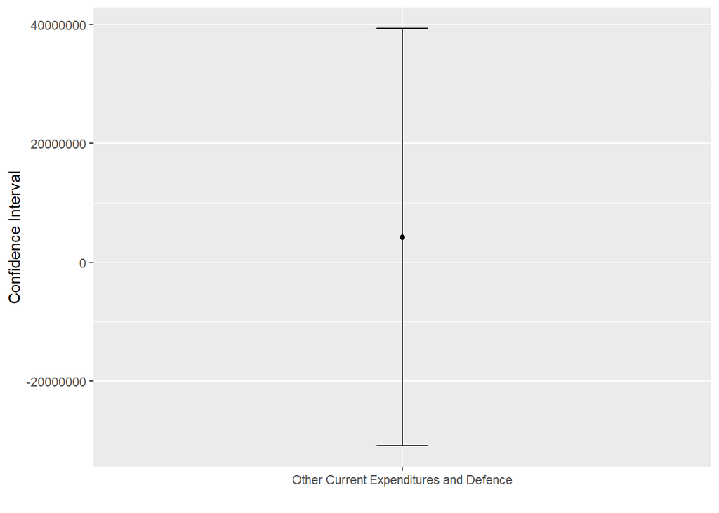

```r
#Then confidence intervals was plotted for both.
ci.plot("Other Current Expenditures and Defence",xbar14-xbar15,E12,E12,'add')
```

```r
"FOR CURRENT EXPENDITURES and DEFENCE CONFIDENCE INTERVALS ON MEANS"
```

```
## [1] "FOR CURRENT EXPENDITURES and DEFENCE CONFIDENCE INTERVALS ON MEANS"
```

```r
#Samples size, samples mean and standard deviation of samples was called.
n16<- length(data_22$CE) ; n16
```

```
## [1] 42
```

```r
n17<- length(data_22$D) ;n17
```

```
## [1] 42
```

```r
xbar16<-mean(data_22$CE);  xbar16
```

```
## [1] 467141360
```

```r
xbar17<- mean(data_22$D);  xbar17
```

```
## [1] 68808754
```

```r
sd16<-sd(data_22$CE); sd16
```

```
## [1] 657878573
```

```r
sd17<-sd(data_22$D); sd17
```

```
## [1] 91449014
```

```r
#zsum.test() function from the BSDA package was used. Since sample size is greater than 30 , we can approximately use z-statistic and then  the 95% CI was found.
zsum.test(xbar16, sd16, n16, xbar17, sd17, n17, alternative="two.sided", conf.level=0.95)
```

```
##
##  Two-sample z-Test
##
## data:  Summarized x and y
## z = 3.9, p-value = 0.0001
## alternative hypothesis: true difference in means is not equal to 0
## 95 percent confidence interval:
##  197458007 599207206
## sample estimates:
## mean of x mean of y
## 467141360  68808754
```

```r
#The standard error of the difference in means was calculated.
sed13<-sqrt(sd16^2/n16+sd17^2/n17); sed13
```

```
## [1] 102488924
```

```r
# zalpha/2 was multiplied with the standard error of the difference in means and the margin of error was obtained.
E13 <- qnorm(.95)*sed13; E13
```

```
## [1] 168579278
```

```r
#The difference of sample means was added and so,the confidence interval was found.
xbar16-xbar17 + c(-E13, E13)
```

```
## [1] 229753328 566911884
```

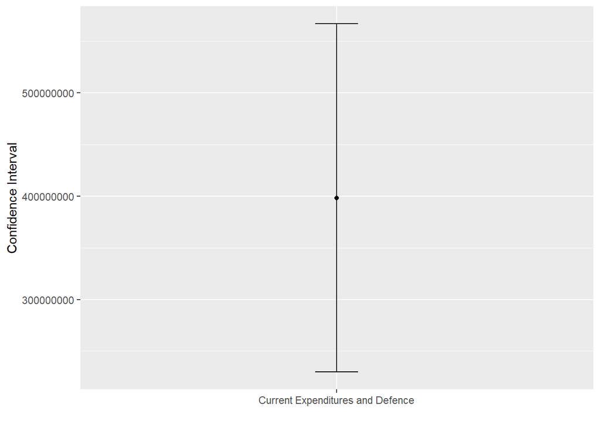

```r
#Then confidence intervals was plotted for both.
ci.plot("Current Expenditures and Defence",xbar16-xbar17,E13,E13,'add')
```

…

#### 3.2.1.4. Confidence Intervals for the Ratio of Population Variances of Two Samples

F test is applied for determining calculating confidence intervals. CI are calculated according to population variances of two samples. …

```r
"FOR  PERSONNEL EXPENDITURES and OTHER CURRENT EXPENDITURES CONFIDENCE INTERVALS ON VARIANCES "
```

```
## [1] "FOR  PERSONNEL EXPENDITURES and OTHER CURRENT EXPENDITURES CONFIDENCE INTERVALS ON VARIANCES "
```

```r
#Samples size and standard deviation of samples was called.
n1<-length(data_22$PE)
n2<-length(data_22$OCE)
sd1<-sd(data_22$PE);sd1
```

```
## [1] 554389981
```

```r
sd2<-sd(data_22$OCE);sd2
```

```
## [1] 103715308
```

```r
#Since, we have two variances,F statistic was used.Then 95% CI was calculated for the two population variances.
fclo <- qf(0.975,n2-1,n1-1,lower=F); fclo
```

```
## [1] 0.5375
```

```r
fcup <- qf(0.025,n2-1,n1-1,lower=F); fcup
```

```
## [1] 1.86
```

```r
sigmasqCI <-(sd1/sd2)^2*c(fclo,fcup); sigmasqCI
```

```
## [1] 15.36 53.16
```

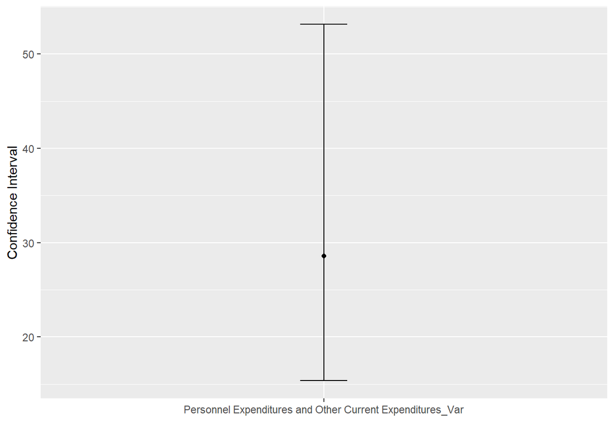

```r
#Confidence interval was plotted.
ci.plot('Personnel Expenditures and Other Current Expenditures_Var',(sd1/sd2)^2,sigmasqCI[1],sigmasqCI[2],'multiply')
```

```r
"FOR  PERSONNEL EXPENDITURES and DEFENCE CONFIDENCE INTERVALS ON VARIANCES "
```

```
## [1] "FOR  PERSONNEL EXPENDITURES and DEFENCE CONFIDENCE INTERVALS ON VARIANCES "
```

```r
#Samples size and standard deviation of samples was called.
n3<-length(data_22$PE);n3
```

```
## [1] 42
```

```r
n4<-length(data_22$D);n4
```

```
## [1] 42
```

```r
sd3<-sd(data_22$PE);sd3
```

```
## [1] 554389981
```

```r
sd4<-sd(data_22$D);sd4
```

```
## [1] 91449014
```

```r
#Since, we have two variances,F statistic was used.Then 95% CI was calculated for the two population variances.
fclo <- qf(0.975,n4-1,n3-1,lower=F); fclo
```

```
## [1] 0.5375
```

```r
fcup <- qf(0.025,n4-1,n3-1,lower=F); fcup
```

```
## [1] 1.86
```

```r
sigmasqCI <-(sd3/sd4)^2*c(fclo,fcup); sigmasqCI
```

```
## [1] 19.75 68.37
```

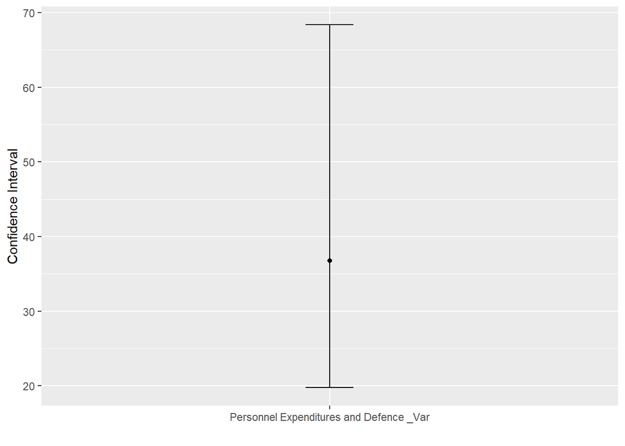

```r
#Confidence interval was plotted.
ci.plot('Personnel Expenditures and Defence _Var',(sd3/sd4)^2,sigmasqCI[1],sigmasqCI[2],'multiply')
```

```r
"FOR OTHER CURRENT EXPENDITURES and DEFENCE CONFIDENCE INTERVALS ON VARIANCES "
```

```
## [1] "FOR OTHER CURRENT EXPENDITURES and DEFENCE CONFIDENCE INTERVALS ON VARIANCES "
```

```r
#Samples size and standard deviation of samples was called.
n5<-length(data_22$OCE);n5
```

```
## [1] 42
```

```r
n6<-length(data_22$D);n6
```

```
## [1] 42
```

```r
sd5<-sd(data_22$OCE);sd5
```

```
## [1] 103715308
```

```r
sd6<-sd(data_22$D);sd6
```

```
## [1] 91449014
```

```r
#Since, we have two variances,F statistic was used.Then 95% CI was calculated for the two population variances.
fclo <- qf(0.975,n6-1,n5-1,lower=F); fclo
```

```
## [1] 0.5375
```

```r
fcup <- qf(0.025,n6-1,n5-1,lower=F); fcup
```

```
## [1] 1.86
```

```r
sigmasqCI <-(sd5/sd6)^2*c(fclo,fcup); sigmasqCI
```

```
## [1] 0.6914 2.3929
```

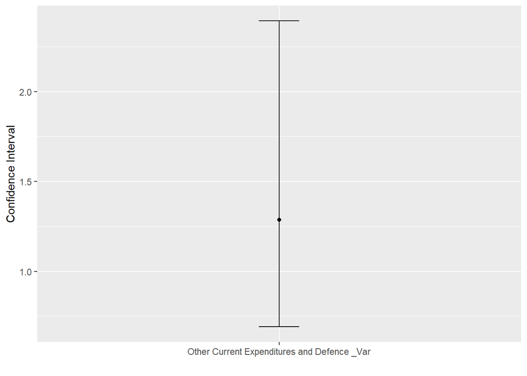

```r
#Confidence interval was plotted.
ci.plot('Other Current Expenditures and Defence _Var',(sd5/sd6)^2,sigmasqCI[1],sigmasqCI[2],'multiply')
```

```r
"FOR CURRENT EXPENDITURES and DEFENCE CONFIDENCE INTERVALS ON VARIANCES "
```

```
## [1] "FOR CURRENT EXPENDITURES and DEFENCE CONFIDENCE INTERVALS ON VARIANCES "
```

```r
#Samples size and standard deviation of samples was called.
n7<-length(data_22$CE);n7
```

```
## [1] 42
```

```r
n8<-length(data_22$D);n8
```

```
## [1] 42
```

```r
sd7<-sd(data_22$CE);sd7
```

```
## [1] 657878573
```

```r
sd8<-sd(data_22$D);sd8
```

```
## [1] 91449014
```

```r
#Since, we have two variances,F statistic was used.Then 95% CI was calculated for the two population variances.
fclo <- qf(0.975,n8-1,n7-1,lower=F); fclo
```

```
## [1] 0.5375
```

```r
fcup <- qf(0.025,n8-1,n7-1,lower=F); fcup
```

```
## [1] 1.86
```

```r
sigmasqCI <-(sd7/sd8)^2*c(fclo,fcup); sigmasqCI
```

```
## [1] 27.82 96.28
```

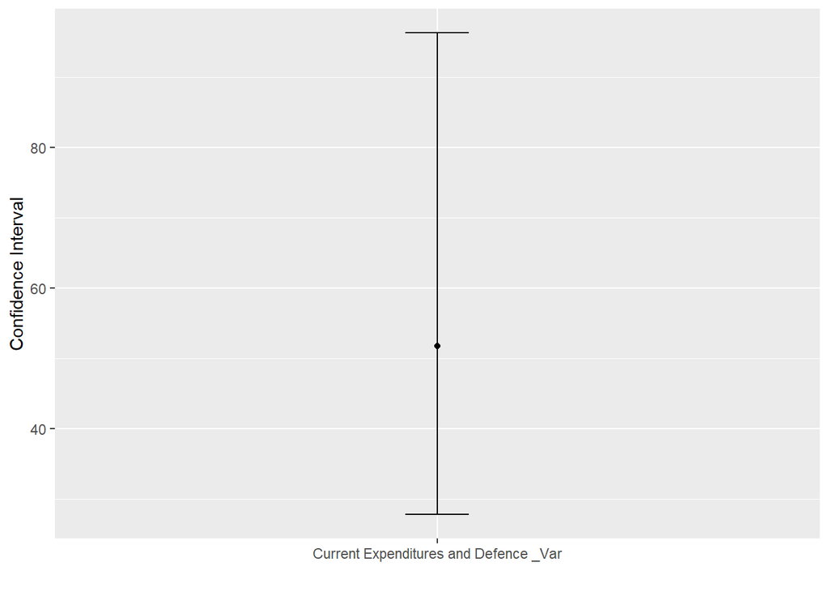

```r
#Confidence interval was plotted.
ci.plot('Current Expenditures and Defence _Var',(sd7/sd8)^2,sigmasqCI[1],sigmasqCI[2],'multiply')
```

…